# R for Bio Data Science

TCGA Pan-Cancer Analysis with Emphasis on Survival Analysis

## Introduction to TCGA Pan-Cancer Dataset

- The Cancer Genome Atlas (TCGA)
- Establishing coordinated effort to characterize molecular events in primary cancers
  - Collection of clinicopathologic annotation data along with multi-platform molecular profiles of more than 11,000 human tumors across 33 different cancer type
- Our data is composed of the 6 cancer types with most patients included
- Significance of the Pan-Cancer dataset in cancer genomics research
- Pan-cancer dataset allows for simultaneous analysis of genomic data across a diverse range of cancer types
- Dataset is crucial for discovering shared molecular features, potential biomarkers and theurapeutic targets
- Contributing to more effective and personalized cancer treatments
- How this dataset helps in understanding cancer at a molecular level
- Data includes genetic mutations, gene expression profiles, epigenetic changes and other molecular alterations associated with diverse cancers
- This dataset facilitates a nuanced understanding of molecular intricacies of cancer
- Data set helps allowing identification of patterns and shared characteristics among different cancer types

## Project Aim and Focus

- To perform an in-depth TCGA Pan-Cancer analysis, focusing on survival analysis
- Explore and understand factors influencing survival outcomes within the TCGA dataset
- Cox proportional hazards models to gain insights into cancer prognosis
- Cox proportional hazard model used in survival analysis to assess impact of covarities

## Data Acquisition and Cleaning

- Data retrieved and loaded using read_excel()
- Raw data is a 11.160 x 34 sized tibble:

| …1 | bcr_patient_barcode | type | age_at_initial_pathologic_diagnosis | gender | race | ajcc_pathologic_tumor_stage | clinical_stage | histological_type | histological_grade | initial_pathologic_dx_year | menopause_status | birth_days_to | vital_status | tumor_status | last_contact_days_to | death_days_to | cause_of_death | new_tumor_event_type | new_tumor_event_site | new_tumor_event_site_other | new_tumor_event_dx_days_to | treatment_outcome_first_course | margin_status | residual_tumor | OS | OS.time | DSS | DSS.time | DFI | … |
| --- | --- | --- | --- | --- | --- | --- | --- | --- | --- | --- | --- | --- | --- | --- | --- | --- | --- | --- | --- | --- | --- | --- | --- | --- | --- | --- | --- | --- | --- | --- |
| 1 | TCGA-OR-A5J1 | ACC | 58 | MALE | WHITE | Stage II | [Not Applicable] | Adrenocortical carcinoma- Usual Type | [Not Available] | 2000 | [Not Available] | -21496 | Dead | WITH TUMOR | NA | 1355 | [Not Available] | Distant Metastasis | Peritoneal Surfaces | NA | 754 | Complete Remission/Response | NA | NA | 1 | 1355 | 1 | 1355 | 1 | … |
| 2 | TCGA-OR-A5J2 | ACC | 44 | FEMALE | WHITE | Stage IV | [Not Applicable] | Adrenocortical carcinoma- Usual Type | [Not Available] | 2004 | [Not Available] | -16090 | Dead | WITH TUMOR | NA | 1677 | [Not Available] | Distant Metastasis | Soft Tissue | NA | 289 | Progressive Disease | NA | NA | 1 | 1677 | 1 | 1677 | NA | … |
| 3 | TCGA-OR-A5J3 | ACC | 23 | FEMALE | WHITE | Stage III | [Not Applicable] | Adrenocortical carcinoma- Usual Type | [Not Available] | 2008 | [Not Available] | -8624 | Alive | WITH TUMOR | 2091 | NA | [Not Available] | Distant Metastasis | Lung | NA | 53 | Complete Remission/Response | NA | NA | 0 | 2091 | 0 | 2091 | 1 | … |

- Initial data exploration:
  - E.g. using slice_head, glimpse and names
  - Identify NAs
- Cleaning:
  - Remove index
  - Assign non-NA missing information to factors
  - Drop columns with >80% missing values
  - Impute remaining NAs: Numeric values to median and categorical values to most frequently occuring string
  - Rename columns for clarification

## Data Transformation and Tools

- Mutate two new columns, by calculating:
  - “age_at_last_followup_years”
  - “disease_duration_years”
- Mutate a new column “age_group_diagnosis” where patients are divided into age categories
- Define function to assign new variable “stage_group” based om:
  - “clinical_stage”
  - “pathological_stage”
- Create subset of the data from the top 6 cancer types:

```r
top_cancer_types <- TCGA_clean |>
  count(cancer_type) |>
  arrange(desc(n)) |>
  slice(1:6) |>
  pull(cancer_type)

TCGA_aug <- TCGA_aug |>
  filter(cancer_type %in% top_cancer_types)
```

- … Leaving us with a new tibble TCGA_aug sized 3.893 x 33 ready for description and analysis

## Interpreting the Model

- Direct comparison of HR across cancer types without stratification
  - Understanding relative risks associated with each factor
- GMB stands out - Risk of death nine times greater
- Age - Risk of death increases slightly with each additional year
- Gender - No significant difference based on gender
- Cancer stage - Stage 4 risk of death six times greater

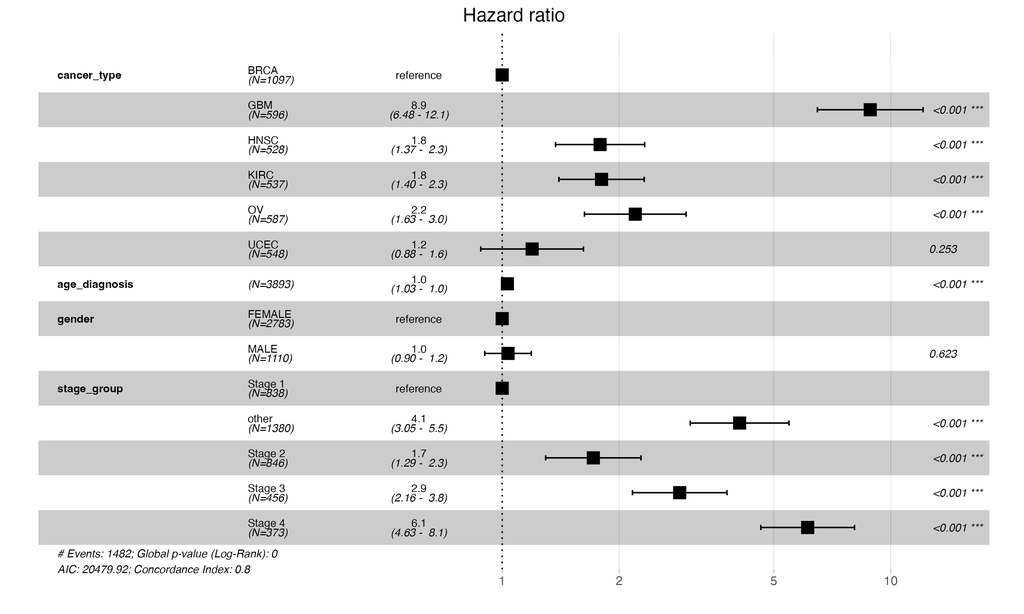

Proportional Hazard Ratio Plot

## Implications and Limitations

- Significance for Oncology

```
-   Cox model identifies survival-related factors
```

```
-   Guides prognosis and treatment strategies
```

```
-   Stresses need for early detection and robust treatments
```

- Study Limitations

```
-   Model may omit key influencing factors (lifestyle, socioeconomics)
```

```
-   Potential unaccounted variable interactions
```

## Conclusion and Future Outlook

- Significance for Oncology

```
  - Employed TCGA Pan-Cancer dataset for survival factor analysis
  - Identified age and cancer type as critical survival predictors
```

- Contribution to Precision Medicine

```
  - Aligns with personalized care based on patient-specific data
  - Promises enhanced predictive accuracy with more genomic information
```

- Future Research Trajectory

```
  - Aims for advanced models to deepen cancer survival understanding
  - Sets a foundation for improved patient treatment and survival rates
```

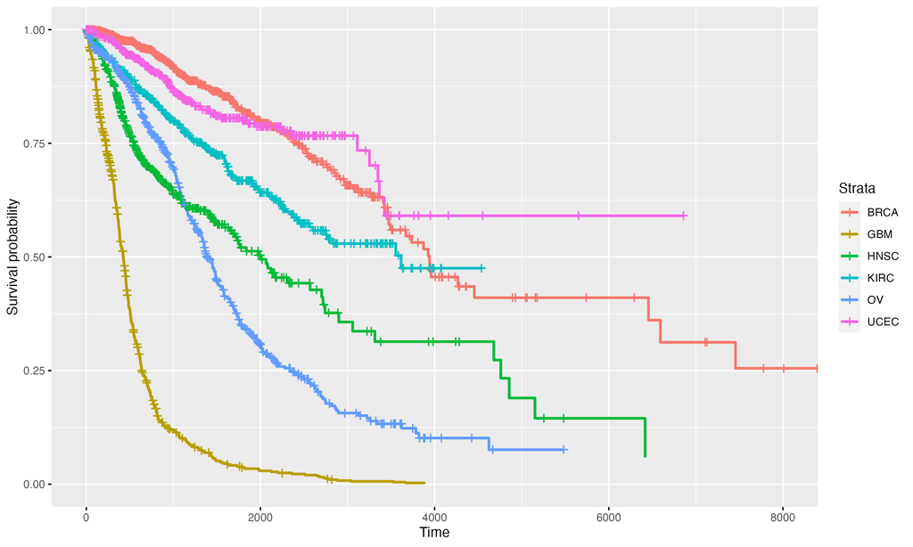

Survival Plot